# R for Data Science

홍우헌

quasar103@naver.com

2018-07-19

> Part 2  
> Wrangle(1)

# 1 Chapter 7 : Tibbles with tibble

```r
as.tibble(iris) # as_tibble()동일
```

```
## # A tibble: 150 x 5
##    Sepal.Length Sepal.Width Petal.Length Petal.Width Species
##           <dbl>       <dbl>        <dbl>       <dbl> <fct>
##  1          5.1         3.5          1.4         0.2 setosa
##  2          4.9         3            1.4         0.2 setosa
##  3          4.7         3.2          1.3         0.2 setosa
##  4          4.6         3.1          1.5         0.2 setosa
##  5          5           3.6          1.4         0.2 setosa
##  6          5.4         3.9          1.7         0.4 setosa
##  7          4.6         3.4          1.4         0.3 setosa
##  8          5           3.4          1.5         0.2 setosa
##  9          4.4         2.9          1.4         0.2 setosa
## 10          4.9         3.1          1.5         0.1 setosa
## # ... with 140 more rows
```

```r
tibble(
  x = 1:5,
  y = 1, # recycle
  z = x ^ 2 + y # 만약 data.frame을 사용하면 여기서 x사용불가
)
```

```
## # A tibble: 5 x 3
##       x     y     z
##   <int> <dbl> <dbl>
## 1     1     1     2
## 2     2     1     5
## 3     3     1    10
## 4     4     1    17
## 5     5     1    26
```

tibble은 `(backtick)을 사용해서 비문법적인 열의 이름을 생성할 수 있다.

```r
tb <- tibble(
  `:)` = "smile", # 특수기호
  ` ` = "space", # 공백
  `2000` = "number" # 숫자
)
tb
```

```
## # A tibble: 1 x 3
##   `:)`  ` `   `2000`
##   <chr> <chr> <chr>
## 1 smile space number
```

`tribble()` 은 열 이름을 formula로 정의되어 지고 엔트리를 콤마로 구분한다.

```r
tribble(
  ~x, ~y, ~z,
#--|--|----
  "a", 2, 3.6,
  "b", 1, 8.5
)
```

```
## # A tibble: 2 x 3
##   x         y     z
##   <chr> <dbl> <dbl>
## 1 a         2   3.6
## 2 b         1   8.5
```

tibble은 기본적으로 10개의 행을 보여주고, 열의 수는 스크린에 맞춰서 보여준다.

```r
tibble(
  a = lubridate::now() + runif(1e3) * 86400,
  b = lubridate::today() + runif(1e3) * 30,
  c = 1:1e3,
  d = runif(1e3),
  e = sample(letters, 1e3, replace = TRUE)
)
```

```
## # A tibble: 1,000 x 5
##    a                   b              c      d e
##    <dttm>              <date>     <int>  <dbl> <chr>
##  1 2018-07-19 19:42:10 2018-08-08     1 0.571  w
##  2 2018-07-20 01:42:43 2018-07-20     2 0.661  j
##  3 2018-07-19 18:40:12 2018-07-19     3 0.629  u
##  4 2018-07-19 21:42:22 2018-08-03     4 0.200  a
##  5 2018-07-19 16:52:39 2018-08-12     5 0.511  h
##  6 2018-07-19 17:03:53 2018-08-13     6 0.0429 g
##  7 2018-07-20 11:38:00 2018-07-20     7 0.864  l
##  8 2018-07-20 04:54:41 2018-08-05     8 0.687  j
##  9 2018-07-20 10:13:56 2018-08-17     9 0.229  k
## 10 2018-07-19 23:55:13 2018-08-10    10 0.703  t
## # ... with 990 more rows
```

`print()`로 출력되는 행의 수와 열의 수를 조정할 수 있다.

```r
flights %>%
  print(n = 10, width = Inf)
```

```
## # A tibble: 336,776 x 19
##     year month   day dep_time sched_dep_time dep_delay arr_time
##    <int> <int> <int>    <int>          <int>     <dbl>    <int>
##  1  2013     1     1      517            515         2      830
##  2  2013     1     1      533            529         4      850
##  3  2013     1     1      542            540         2      923
##  4  2013     1     1      544            545        -1     1004
##  5  2013     1     1      554            600        -6      812
##  6  2013     1     1      554            558        -4      740
##  7  2013     1     1      555            600        -5      913
##  8  2013     1     1      557            600        -3      709
##  9  2013     1     1      557            600        -3      838
## 10  2013     1     1      558            600        -2      753
##    sched_arr_time arr_delay carrier flight tailnum origin dest  air_time
##             <int>     <dbl> <chr>    <int> <chr>   <chr>  <chr>    <dbl>
```

[output cut: 23 more lines]

option으로 defaul print를 조정할 수 있다.

- `options(tibble.print_max = n, tibble.print_min = m)` : m 행보다 크면 n 행을 출력. `options(dplyr.print_min = Inf)`는 항상 모든행 출력
- `options(tibble.width = Inf)` 스크린 너비에 관계없이 모든 열을 보여준다.

## 1.1 Exercises

1. Compare and contrast the following operations on a data.frame and equivalent tibble. What is different? Why might the default data frame behaviors cause you frustration?

```r
df <- data.frame(abc = 1, xyz = "a")
df$x # 출력 o
```

```
## [1] a
## Levels: a
```

```r
df[, "xyz"] # df를 반환하지 않는다.
```

```
## [1] a
## Levels: a
```

```r
df[, c("abc", "xyz")] # df반환
```

```
##   abc xyz
## 1   1   a
```

```r
df <- tibble(abc = 1, xyz = "a")
df$x # 출력 x
```

```r
df[, "xyz"] # df 반환
```

```
## # A tibble: 1 x 1
##   xyz
##   <chr>
## 1 a
```

```r
df[, c("abc", "xyz")] # df 반환
```

```
## # A tibble: 1 x 2
##     abc xyz
##   <dbl> <chr>
## 1     1 a
```

2. If you have the name of a variable stored in an object, e.g., var <- “mpg”, how can you extract the reference variable from a tibble?

```r
df <- tibble(mpg = "haha")
var <- "mpg"
df[, var]
```

```
## # A tibble: 1 x 1
##   mpg
##   <chr>
## 1 haha
```

```r
df[var]
```

```
## # A tibble: 1 x 1
##   mpg
##   <chr>
## 1 haha
```

```r
df[[var]] # 벡터 출력
```

```
## [1] "haha"
```

```r
df$var # $는 사용불가
```

3. Practice referring to nonsyntactic names in the following data frame by:
1. Extracting the variable called 1.
2. Plotting a scatterplot of 1 versus 2.
3. Creating a new column called 3, which is 2 divided by 1.
4. Renaming the columns to one, two, and three:

annoying <- tibble( `1` = 1:10, `2` = `1` * 2 + rnorm(length(`1`)) )

```r
annoying <- tibble(
  `1` = 1:10,
  `2` = `1` * 2 + rnorm(length(`1`))
)
```

```r
annoying[["1"]] # `1`은 안되고 1은 됨
```

```
##  [1]  1  2  3  4  5  6  7  8  9 10
```

```r
annoying$`1` # `1`과 "1"은 되고 1은 안됨
```

```
##  [1]  1  2  3  4  5  6  7  8  9 10
```

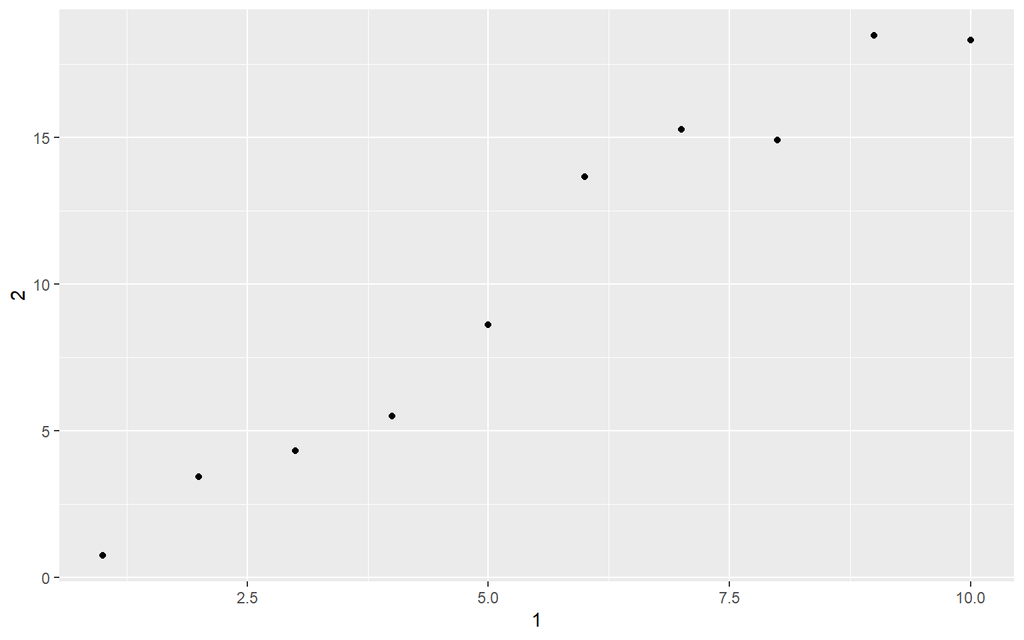

```r
ggplot(annoying, aes(`1`, `2`)) + # ` `를 잊지말자
  geom_point()
```

```r
annoying <- mutate(annoying, `3` = `2` / `1`)
# annoying[["3"]] <- annoying$`2` / annoying$`1`
# annoying[["3"]] <- annoying[["2"]] / annoying[["1"]]

colnames(annoying) <- c("잠", "온", "다")
glimpse(annoying)
```

```
## Observations: 10
## Variables: 3
## $ 잠 <int> 1, 2, 3, 4, 5, 6, 7, 8, 9, 10
## $ 온 <dbl> 0.7351174, 3.4313704, 4.3184986, 5.4930196, 8.6213498, 13.6719...
## $ 다 <dbl> 0.7351174, 1.7156852, 1.4394995, 1.3732549, 1.7242700, 2.27866...
```

4. What does tibble::enframe() do? When might you use it?

```r
enframe(c(a = 1, b = 3))
```

```
## # A tibble: 2 x 2
##   name  value
##   <chr> <dbl>
## 1 a         1
## 2 b         3
```

```r
enframe(1:5)
```

```
## # A tibble: 5 x 2
##    name value
##   <int> <int>
## 1     1     1
## 2     2     2
## 3     3     3
## 4     4     4
## 5     5     5
```

# 2 Chapter 8 : Data Import with readr

- `read_csv()` : 콤마로 구분한 파일을 읽는다. `read_csv2()` : 세미클론으로 구분한 파일을 읽는다. `read_tsv()` : 탭으로 구분한 파일을 읽는다. `read_delim()` : 특정 구분자로 구분한 파일을 읽는다.
- `read_fwf()` : 너비가 고정된 파일을 읽는다. `read_table()` : 열이 공백으로 구분되어지는 너비가 고정된 파일의 변형이다.
- `read_log()` : Apache style log file을 읽는다.

`read_csv()` 의 첫번째 인자는 path(파일경로)이다. read_csv()는 첫번째 라인을 열의 이름으로 인식한다.

```r
read_csv("a,b,c
  1,2,3
  4,5,6")
```

```
## # A tibble: 2 x 3
##       a     b     c
##   <int> <int> <int>
## 1     1     2     3
## 2     4     5     6
```

- 메타데이터의 몇가지 라인을 스킵한다.

```r
read_csv("The first line of metadata
  The second line of metadata
  x,y,z
  1,2,3", skip = 2)
```

```
## # A tibble: 1 x 3
##       x     y     z
##   <int> <int> <int>
## 1     1     2     3
```

comment = “#”은 #로 시작하는 모든 라인을 스킵한다.

```r
read_csv("# A comment I want to skip
  x,y,z
  1,2,3", comment = "#")
```

```
## # A tibble: 1 x 3
##       x     y     z
##   <int> <int> <int>
## 1     1     2     3
```

- 데이타가 열의 이름을 가지고 있지 않다면 `col_names = FALSE`

```r
read_csv("1,2,3\n4,5,6", col_names = FALSE)
```

```
## # A tibble: 2 x 3
##      X1    X2    X3
##   <int> <int> <int>
## 1     1     2     3
## 2     4     5     6
```

```r
read_csv("1,2,3\n4,5,6", col_names = c("x", "y", "z"))
```

```
## # A tibble: 2 x 3
##       x     y     z
##   <int> <int> <int>
## 1     1     2     3
## 2     4     5     6
```

NA를 설정할 수 있다.

```r
read_csv("a,b,c\n1,2,.", na = ".")
```

```
## # A tibble: 1 x 3
##       a     b c
##   <int> <int> <chr>
## 1     1     2 <NA>
```

### 2.0.1 Base R과의 비교

read.csv()보다 좋은점

- 10배까지 빠르다. 그렇지만 data.table::fread()가 더 빠르다.
- tibble을 생성하고 문자형 벡터를 팩터로 변환시키지 않고 행 이름을 사용하거나 열 이름을 munge(개조..?)하지 않는다.
- 좀 더 재현가능하다. Base R 함수는 OS와 환경변수로 부터 상속해서 다른 사람의 컴퓨터에서는 중요한 코드가 작동하지 않을지도 모른다.

## 2.1 Exercises

1. What function would you use to read a file where fields are separated with “|”?

```r
read_delim("a|b\n1.0|2.0", delim = "|")
```

```
## # A tibble: 1 x 2
##       a     b
##   <dbl> <dbl>
## 1     1     2
```

2. Apart from file, skip, and comment, what other arguments do read_csv() and read_tsv() have in common?

```r
intersect(names(formals(read_csv)), names(formals(read_tsv)))
```

```
##  [1] "file"      "col_names" "col_types" "locale"    "na"        "quoted_na"
##  [7] "quote"     "comment"   "trim_ws"   "skip"      "n_max"     "guess_max"
## [13] "progress"
```

- `col_names` and `col_types` : 열 이름을 구체화하고 열 이름을 parse한다.
- `locale` : “.” 또는 “,”가 소수점으로 이용될 때 중요
- `na` and `quoted_na` : 문자열이 벡터를 parsing할 때 NA로 다뤄지는 것을 통제한다.
- `trim_ws` : 셀을 parsing하기 전에 공백을 제거한다.
- `n_max` : 읽어들일 행의 수 설정
- `guess_max` : 열의 타입을 생각했을 때 얼마나 많은 행을 사용할지 설정한다.
- `progress` : progress bar가 보여질지 여부를 결정
3. What are the most important arguments to read_fwf()?

`col_positions` : fwf_empty(), fwf_widths() or fwf_positions()

4. Sometimes strings in a CSV file contain commas. To prevent them from causing problems they need to be surrounded by a quoting character, like " or ’. By convention, read_csv() assumes that the quoting character will be “, and if you want to change it you’ll need to use read_delim() instead. What arguments do you need to specify to read the following text into a data frame?

```r
x <- "x,y\n1,'a,b'"
read_delim(x, "," , quote = "'") # 두번째 인자는 delim이다
```

```
## # A tibble: 1 x 2
##       x y
##   <int> <chr>
## 1     1 a,b
```

5. Identify what is wrong with each of the following inline CSV files. What happens when you run the code?

```r
read_csv("a,b\n1,2,3\n4,5,6") # 3과 6이 제거
```

```
## # A tibble: 2 x 2
##       a     b
##   <int> <int>
## 1     1     2
## 2     4     5
```

```r
read_csv("a,b,c\n1,2\n1,2,3,4")
```

```
## # A tibble: 2 x 3
##       a     b     c
##   <int> <int> <int>
## 1     1     2    NA
## 2     1     2     3
```

```r
read_csv("a,b\n\"1") #
```

```
## # A tibble: 1 x 2
##       a b
##   <int> <chr>
## 1     1 <NA>
```

```r
read_csv("a,b\n1,2\na,b")
```

```
## # A tibble: 2 x 2
##   a     b
##   <chr> <chr>
## 1 1     2
## 2 a     b
```

```r
read_csv("a;b\n1;3") # read_csv2() 사용
```

```
## # A tibble: 1 x 1
##   `a;b`
##   <chr>
## 1 1;3
```

## 2.2 Pasring a Vector

readr이 디스크로부터 파일을 어떻게 가져오는지 이야기하기전에, parse_*() 함수에 대해 이야기 해보자. 이런 함수들은 문자형 벡터를 취해서 논리, 정수, 날짜 같은 벡터로 반환한다.

```r
str(parse_logical(c("TRUE", "FALSE", "NA")))
```

```
##  logi [1:3] TRUE FALSE NA
```

```r
str(parse_integer(c("1", "2", "3")))
```

```
##  int [1:3] 1 2 3
```

```r
str(parse_date(c("2010-01-01", "1979-10-14")))
```

```
##  Date[1:2], format: "2010-01-01" "1979-10-14"
```

```r
parse_integer(c("1", "231", ".", "456"), na = ".")
```

```
## [1]   1 231  NA 456
```

parsing에 실패하면 경고

```r
x <- parse_integer(c("123", "345", "abc", "123.45"))
```

[output not shown]

[output not shown]

```r
x
```

```
## [1] 123 345  NA  NA
## attr(,"problems")
## # A tibble: 2 x 4
##     row   col expected               actual
##   <int> <int> <chr>                  <chr>
## 1     3    NA an integer             abc
## 2     4    NA no trailing characters .45
```

많은 parsing failure가 있다면, problems()를 사용하라.

```r
problems(x)
```

```
## # A tibble: 2 x 4
##     row   col expected               actual
##   <int> <int> <chr>                  <chr>
## 1     3    NA an integer             abc
## 2     4    NA no trailing characters .45
```

- `parse_logical()` and `parse_integer()` 논리형과 정수형을 parse한다.
- `parse_double()` 엄밀한 수치 parser, `parse_number()` 유연한 수치 parser.
- `parse_character()`
- `parse_factor()`
- `parse_datetime()`, `parse_date()`, and `parse_time()` . 날짜를 쓰는 다양한 방법때문에 가장 복잡하다.

### 2.2.1 Numbers

숫자를 parse 한느 것은 간단해야 하지만 세가지의 그것을 어렵게 하는 문제가 있다.

- 사람들은 숫자를 다르게 쓴다. 예를 들어, .과 ,의 사용
- $1000과 10%같이 숫자 주변에 문자가 있는 경우
- 1,000,000과 같이 “grouping” 문자를 포함하는 경우

첫번째 문제를 다루기 위해, locale 인자를 가지고 있다.

```r
parse_double("1.23")
```

```
## [1] 1.23
```

```r
parse_double("1,23", locale = locale(decimal_mark = ","))
```

```
## [1] 1.23
```

readr의 디폴트 locale은 미국표준.

`parse_number()`는 두번째 문제를 다룬다.

```r
parse_number("$100")
```

```
## [1] 100
```

```r
parse_number("20%")
```

```
## [1] 20
```

```r
parse_number("It cost $123.45") # 문자내에 숫자 추출 가능
```

```
## [1] 123.45
```

세번째 문제는 `parse_number()`과 `locale`의 조합으로 “grouping mark”를 무시한다.

```r
# Used in America
parse_number("$123,456,789")
```

```
## [1] 123456789
```

```r
# Used in many parts of Europe
parse_number(
  "123.456.789",
  locale = locale(grouping_mark = ".")
)
```

```
## [1] 123456789
```

```r
# Used in Switzerland
parse_number(
  "123'456'789",
  locale = locale(grouping_mark = "'")
)
```

```
## [1] 123456789
```

### 2.2.2 Strings

`parse_character()`는 단순히 입력값을 반환하지만 같은 문자열을 나타내는 많은 방법이 있다. R에서 문자열 표현 방식을 보면

```r
charToRaw("Woohun")
```

```
## [1] 57 6f 6f 68 75 6e
```

16진법 수아 정보를 나타내고 있다. 16진법수에서 문자로 매핑하는것을 인코딩이라고 하며, 여기서의 인코딩은 ASCII이다. ASCII는 영어 문자를 나타내기에 좋다.

영어를 제외하면 복잡하지만 UTF-8이 거의 모든걸 지원해준다.

readr은 UTF-8을 모든곳에서 사용한다. 데이터를 읽을 때 UTF-8로 인코딩되어 있다고 가정한다. 하지만 오래된 시스템에서는 UTF-8을 이해 못할 수 있다.

```r
x1 <- "El Ni\xf1o was particularly bad this year"
x2 <- "\x82\xb1\x82\xf1\x82\xc9\x82\xbf\x82\xcd"

parse_character(x1, locale = locale(encoding = "Latin1"))
```

```
## [1] "El Nino was particularly bad this year"
```

```r
parse_character(x2, locale = locale(encoding = "Shift-JIS"))
```

```
## [1] "こんにちは"
```

문서에 인코딩 방법이 적혀있지 않다면 `guess_encoding()`을 사용해 보라.

```r
guess_encoding(charToRaw(x1))
```

```
## # A tibble: 2 x 2
##   encoding   confidence
##   <chr>           <dbl>
## 1 ISO-8859-1       0.46
## 2 ISO-8859-9       0.23
```

```r
guess_encoding(charToRaw(x2))
```

```
## # A tibble: 1 x 2
##   encoding confidence
##   <chr>         <dbl>
## 1 KOI8-R         0.42
```

인코딩에 관해서는 다음 문서를 참고해 보라.http://kunststube.net/encoding/

### 2.2.3 Factors

```r
fruit <- c("apple", "banana")
parse_factor(c("apple", "banana", "bananana"), levels = fruit)
```

```
## [1] apple  banana <NA>
## attr(,"problems")
## # A tibble: 1 x 4
##     row   col expected           actual
##   <int> <int> <chr>              <chr>
## 1     3    NA value in level set bananana
## Levels: apple banana
```

### 2.2.4 Dates, Date-Times, and Times

date (the number of days since 1970-01-01), a date-time (the number of seconds since midnight 1970-01-01), or a time (the number of seconds since midnight)

- `parse_datetime()` ISO8601 date-time일 것이다. ISO8601은 날짜의 국제적 표준. year, month, day, hour, minute, second

```r
parse_datetime("2010-10-01T2010")
```

```
## [1] "2010-10-01 20:10:00 UTC"
```

```r
parse_datetime("20101010")
```

```
## [1] "2010-10-10 UTC"
```

- `parse_date()`

```r
parse_date("2010-10-01")
```

```
## [1] "2010-10-01"
```

- parse_time()

```r
library(hms)
parse_time("01:10 am")
```

```
## 01:10:00
```

```r
parse_time("20:10:01")
```

```
## 20:10:01
```

Year %Y (4 digits). %y (2 digits; 00-69 → 2000-2069, 70-99 → 1970-1999).

Month %m (2 digits). %b (abbreviated name, like “Jan”). %B (full name, “January”).

Day %d (2 digits). %e (optional leading space).

Time %H (0-23 hour format). %I (0-12, must be used with %p). %p (a.m./p.m. indicator). %M (minutes). %S (integer seconds). %OS (real seconds). %Z (time zone [a name, e.g., America/Chicago]). %z (as offset from UTC, e.g., +0800).

Nondigits %. (skips one nondigit character). %* (skips any number of nondigits).

올바른 포맷을 이해하는데에 가장 좋은 방법은 문자형 벡터로 몇가지 예를 만드는 것이다.

```r
parse_date("01/02/15", "%m/%d/%y")
```

```
## [1] "2015-01-02"
```

```r
parse_date("01/02/15", "%d/%m/%y")
```

```
## [1] "2015-02-01"
```

```r
parse_date("01/02/15", "%y/%m/%d")
```

```
## [1] "2001-02-15"
```

```r
parse_date("1 janvier 2015", "%d %B %Y", locale = locale("fr"))
```

```
## [1] "2015-01-01"
```

## 2.3 Exercises

1. What are the most important arguments to locale()?

date and time formats: date_names, date_format, and time_format time_zone: tz numbers: decimal_mark, grouping_mark encoding: encoding

2. I didn’t discuss the date_format and time_format options to locale(). What do they do? Construct an example that shows when they might be useful.

```r
parse_datetime("14 oct. 1979 07:50:00 PM", "%d %b %Y %H:%M:%S %p", locale = locale("fr"))
```

```
## [1] "1979-10-14 19:50:00 UTC"
```

4. If you live outside the US, create a new locale object that encapsulates the settings for the types of files you read most commonly.

```r
parse_date("2018 7 19", "%Y %m %d", locale = locale("ko"))
```

```
## [1] "2018-07-19"
```

5. What’s the difference between read_csv() and read_csv2()?

read_csv()는 구분자가 콤마이고 read_csv2()는 세미클론이다.

6. What are the most common encodings used in Europe? What are the most common encodings used in Asia? Do some googling to find out.

r4ds solution 참고

7. Generate the correct format string to parse each of the following dates and times:

```r
d1 <- "January 1, 2010"
parse_date(d1, "%B %d, %Y")
```

```
## [1] "2010-01-01"
```

```r
d2 <- "2015-Mar-07"
parse_date(d2, "%Y-%b-%d")
```

```
## [1] "2015-03-07"
```

```r
d3 <- "06-Jun-2017"
parse_date(d3, "%d-%b-%Y")
```

```
## [1] "2017-06-06"
```

```r
d4 <- c("August 19 (2015)", "July 1 (2015)")
parse_date(d4, "%B %d (%Y)")
```

```
## [1] "2015-08-19" "2015-07-01"
```

```r
d5 <- "12/30/14" # Dec 30, 2014
parse_date(d5, "%D")
```

```
## [1] "2014-12-30"
```

```r
t1 <- "1705"
parse_time(t1, "%H%M")
```

```
## 17:05:00
```

```r
t2 <- "11:15:10.12 PM"
parse_time(t2, "%H:%M:%OS %p")
```

```
## 23:15:10.12
```

## 2.4 Parsing a File

rear이 파일을 parse하는 방법을 탐색해보자.

- readr이 자동적으로 각 열의 타입을 추측하는 방법
- 디폴트 사양을 오버라이드 하는 방법

### 2.4.1 Strategy

readr은 1000개의 행을 읽고 데이터 타입을 정한다.

```r
# emulate 가능
guess_parser("2010-01-01")
```

```
## [1] "date"
```

```r
guess_parser("15:01")
```

```
## [1] "time"
```

```r
guess_parser(c("TRUE", "FALSE"))
```

```
## [1] "logical"
```

logical : Contains only “F”, “T”, “FALSE”, or “TRUE”. integer : Contains only numeric characters (and -). double : Contains only valid doubles (including numbers like 4.5e-5). number : Contains valid doubles with the grouping mark inside. time : Matches the default time_format. date : Matches the default date_format. date-time : Any ISO8601 date.

If none of these rules apply, then the column will stay as a vector of strings.

### 2.4.2 Problems

- 첫번째 수천행이 특수한 경우일 수 있고, readr은 충분하게 일반적이지 않은 유형을 생각.
- 열이 많은 NA를 포함할 수 있다.

```r
challenge <- read_csv(readr_example("challenge.csv"))
problems(challenge)
```

```
## # A tibble: 1,000 x 5
##      row col   expected               actual             file
##    <int> <chr> <chr>                  <chr>              <chr>
##  1  1001 x     no trailing characters .23837975086644292 'C:/Users/user123/~
##  2  1002 x     no trailing characters .41167997173033655 'C:/Users/user123/~
##  3  1003 x     no trailing characters .7460716762579978  'C:/Users/user123/~
##  4  1004 x     no trailing characters .723450553836301   'C:/Users/user123/~
##  5  1005 x     no trailing characters .614524137461558   'C:/Users/user123/~
##  6  1006 x     no trailing characters .473980569280684   'C:/Users/user123/~
##  7  1007 x     no trailing characters .5784610391128808  'C:/Users/user123/~
##  8  1008 x     no trailing characters .2415937229525298  'C:/Users/user123/~
##  9  1009 x     no trailing characters .11437866208143532 'C:/Users/user123/~
## 10  1010 x     no trailing characters .2983446326106787  'C:/Users/user123/~
## # ... with 990 more rows
```

```r
challenge <- read_csv(
  readr_example("challenge.csv"),
  col_types = cols(
    x = col_integer(),
    y = col_character()
  )
)
# 첫번째 문제 해결
challenge <- read_csv(
  readr_example("challenge.csv"),
  col_types = cols(
    x = col_double(),
    y = col_character()
  )
)
```

```r
tail(challenge)
```

```
## # A tibble: 6 x 2
##       x y
##   <dbl> <chr>
## 1 0.805 2019-11-21
## 2 0.164 2018-03-29
## 3 0.472 2014-08-04
## 4 0.718 2015-08-16
## 5 0.270 2020-02-04
## 6 0.608 2019-01-06
```

```r
# 두번째 문제 해결
challenge <- read_csv(
  readr_example("challenge.csv"),
  col_types = cols(
    x = col_double(),
    y = col_date()
  )
)
```

`col_types`를 사용해서 일관적이고 재현가능한 데이터 import script을 보장하라.

### 2.4.3 Other Strategies

- 1000번째 이후의 행까지 읽으면 제대로 된 타입을 알 수 있을 수도 있다.

```r
challenge2 <- read_csv(
  readr_example("challenge.csv"),
  guess_max = 1001
)
```

- 단순히 문자형 벡터로 읽어 들임으로써 문제를 진단할 수 있다.

```r
challenge2 <- read_csv(readr_example("challenge.csv"),
  col_types = cols(.default = col_character())
)
```

이것은 `type_convert()`와 함께 사용하면 유용하다.

```r
df <- tribble(
  ~x, ~y,
  "1", "1.21",
  "2", "2.32",
  "3", "4.56"
)

type_convert(df)
```

```
## # A tibble: 3 x 2
##       x     y
##   <int> <dbl>
## 1     1  1.21
## 2     2  2.32
## 3     3  4.56
```

- 굉장히 큰 파일을 읽는다면, `n_max` (Maximum number of records to read.) 를 사용하라.
- `read_lines()` 로 문자형 벡터로써 읽거나 `read_file()`로 길이1의 문자형 벡터로 읽을 수도 있다. 그 다음에 string parsing skills를 사용하라.

## 2.5 Writing to a File

`write_csv()` 와 `write_tsv()`는 올바르게 읽을 가능성을 증가시키는데

- 항상 문자열을 UTF-8로 인코딩
- dates and date-times을 pasing되기 쉽게 ISO8601 포멧으로 저장한다.

CSV 파일을 Excel로 내보낼 때, `write_excel_csv()`를 사용하라.

가장중요한 인자는 x와 path이다. NA를 구체적으로 정하고, 만약 파일을 첨부하기를 원하면

```r
write.csv(challenge, "challenge.csv")
```

CSV로 저장할 때 type 정보를 잃는다는 사실에 주의하라

```r
write_csv(challenge, "challenge-2.csv")
read_csv("challenge-2.csv")
```

```
## # A tibble: 2,000 x 2
##        x y
##    <int> <chr>
##  1   404 <NA>
##  2  4172 <NA>
##  3  3004 <NA>
##  4   787 <NA>
##  5    37 <NA>
##  6  2332 <NA>
##  7  2489 <NA>
##  8  1449 <NA>
##  9  3665 <NA>
## 10  3863 <NA>
## # ... with 1,990 more rows
```

로드 할 때마다 데이터 타입을 정해줘야 하므로 다른 대안을 사용하자

- `write_rds()` and `read_rds()`는 베이스 함수의 readRDS() and saveRDS()의 wrapper이다. 이것들은 R의 바이너리 포멧으로 저장한다.

```r
write_rds(challenge, "challenge.rds")
read_rds("challenge.rds")
```

```
## # A tibble: 2,000 x 2
##        x y
##    <dbl> <date>
##  1   404 NA
##  2  4172 NA
##  3  3004 NA
##  4   787 NA
##  5    37 NA
##  6  2332 NA
##  7  2489 NA
##  8  1449 NA
##  9  3665 NA
## 10  3863 NA
## # ... with 1,990 more rows
```

- *feather* 패키지는 프로그래밍 언어 마다 공유되어지는 빠른 바이너리 파일 포멧을 실현한다. RDS 보다 빠르고 R밖에서도 사용이 가능하다.

```r
# devtools::install_github("wesm/feather/R")
library(feather)
write_feather(challenge, "challenge.feather")
read_feather("challenge.feather")
```

```
## # A tibble: 2,000 x 2
##        x y
##    <dbl> <date>
##  1   404 NA
##  2  4172 NA
##  3  3004 NA
##  4   787 NA
##  5    37 NA
##  6  2332 NA
##  7  2489 NA
##  8  1449 NA
##  9  3665 NA
## 10  3863 NA
## # ... with 1,990 more rows
```